# Retailer Forecast

## **Part 1 | Data Analysis**

### **Task Overview**

The provided datasets contains customer and marketing information for a **Men's Fashion Retailer**. The goal of this analysis is to identify key areas where the retailer should focus its efforts, particularly in terms of channel performance, demographic patterns, or customer behavior trends. To achieve this, I first addressed any data formatting inconsistencies to ensure the dataset was prepared for further analysis.

I began by reviewing the structure of the dataset and identifying notable trends or potential inconsistencies. Following that, I conducted deeper analysis to explore performance metrics, customer segmentation, and any other insights that could inform strategy. Finally, I summarized my findings in the conclusion section.

### The following sections consist of:

- **Initial Observation**
- **Data Cleaning and Exploration**
- **Analysis**
- **Conclusion**

## **Initial Observations**

The data was originally provided in Google Sheets in `.XLSX` format. Initially, I downloaded the dataset in `.csv` format for ease of use with Excel and Python. However, after encountering several formatting issues, such as with date fields and currency symbols, I realized the conversion process from Google Sheets to `.csv` was introducing errors.

This became particularly evident when I reviewed the Cost Data sheet, where symbols like € were lost during the conversion, and the numeric values were not properly preserved. Additionally, I noticed issues with the Demographic Info dataset, where dates were misformatted, leading to text-based values instead of numeric date values.

To address these problems, I re-downloaded the dataset in `.XLSX` format directly from Google Sheets, which preserved the correct formatting. Then, I opened the `.XLSX` file in Excel and converted it to `.csv` from there, setting me up for further exploration in Python. This resolved the formatting issues across the files, including date and currency symbol problems.

**More detailed documentation of how I came across these issues is described in the Cost Dataset section below.**

Below I discuss my initial findings in each dataset I genderated from the `.XLSX` file

#### **Demographic Info DataSet:**

[figure not shown]

  As an additional note, the "Registration Date" column also included hour and minute for each date, displayed in 24-hour time. Again, due to the incorrect set up of the formatting, some were stored as numeric dates, while others were stored as text.
- I wanted to check that the "Date of Birth" column was also consistent with its formatting. While doing this, I found that the customer year of birth ranged from 1916-1993.
- The unique identifier column seemed consistent, with no duplicates
- The "Address City" column displays address information as towns or counties. For example, certain places are displayed as "Malahide", "Swords", or "Tallaght", and others just as "Dublin". However, the problem here is that each of these places are in Dublin. As this introduces too much complexity, I decided to ignore this column during my demographic analysis.
- The "Contact Allowed" and "Source of Customer" columns didn't seem to have missing information

#### **Cost DataSet:**

When looking at the cost data, I noticed there were formatting issues again. The numeric data in its original file contained € symbols. However, upon converting to `.csv` from Google Sheets, data conversion issues arised again:

[figure not shown]

This is where I decided to download the file from Google Sheets as `.XLSL`, open it in Excel, and then download each sheet as a `.csv` file instead. All formatting issues had now been resolved.

[figure not shown]

#### **Value Info Dataset:**

- The "Customer ID" column values were not stored sequentially, some numbers were skipped, possibly indicating a portion of customers' data was deleted from the database in the past.
- The "1st Order Profit", "Second Order Profit", and "Total value of all promotions" columns, stored their numbers to their exact decimal value, although their whole number value only showed up upon inital display.

[figure not shown]

  I found this particularly interesting. Due to the limitations of the available information, I theorized that this level of precision may be a result of accounting for components such as tax, shipping, or other marginal costs. Another possibility is that the data was originally recorded in a different currency, and after conversion, it resulted in these precise floating-point numbers. Regardless of how the data was generated, I knew I would still be able to perform accurate profit margin calculations with it.
- The "Subsequent Orders Count" column seemed to have no missign value

## Data Cleaning and Exploration

In this section, I took a closer look at the initial observations to gain a clearer understanding of both the marketing channels and customer demographics. As I explored the data, I addressed any inconsistencies or formatting issues to ensure it was ready for deeper analysis. This process involved cleaning the data as I went along, correcting any errors that could affect the quality of insights.

While there wasn't much cleaning to be done, this prepared the data for the subsequent Analysis section, where I dive into customer acquisition, repeat purchase behaviour, profit analysis, and a forecast of profits by marketing channel.

#### Importing all needed datasets:

```python
# begin by using pands module for data manipulation
import pandas as pd

# set display settings to make pandas output more readable
pd.set_option('display.max_rows', False)
pd.set_option('display.max_columns', None)


demographic_info_df = pd.read_csv("Data/demographic_info.csv")
value_info_df = pd.read_csv("Data/value_info.csv")
cost_df = pd.read_csv("Data/cost.csv")
```

#### Checking if the data was imported correctly:

```python
print(demographic_info_df.head())
```

```
   Customer ID Title Date Of Birth Address City Contact Allowed  \
0            1    Mr    29/06/1973     Malahide               Y
1            2    Mr    25/07/1984       Dublin               Y
2            3    Mr    01/05/1991       Dublin               Y
3            4    Mr    30/11/1986       Dublin               N
4            5    Mr    02/10/1991     Limerick               Y

  Registration Date Source of Customer
0  01/01/2013 00:23     Organic Search
1  01/01/2013 00:30         Affiliates
2  01/01/2013 01:09        Paid Social
3  01/01/2013 01:19         Affiliates
4  01/01/2013 01:58        Paid Search
```

```python
print(value_info_df.head())
```

```
   Customer ID  1st Order Profit  Subsequent Order Profit  \
0            1                 9                        5
1            2                 8                       70
2            3                14                       51
3            4                14                        0
4            5                23                       68

   Subsequent Orders Count  Total value of all promotions
0                        1                              7
1                        7                              7
2                        7                              0
3                        0                              0
4                        9                             15
```

```python
print(cost_df.head())
```

```
    Month Paid Search   Affiliates  Unnamed: 3  Unnamed: 4  Unnamed: 5
0  Jan-13  €41,512.00   €16,421.00         NaN         NaN         NaN
1  Feb-13  €61,243.00   €42,101.00         NaN         NaN         NaN
2  Mar-13  €84,597.88  €141,321.00         NaN         NaN         NaN
3     NaN         NaN          NaN         NaN         NaN         NaN
4     NaN         NaN          NaN         NaN         NaN         NaN
```

```python
# the cost table has extra unanmed columns so drop them
cost_df= cost_df.dropna(axis=1, how='all')

# it has unamed rows too, drop them
cost_df = cost_df.dropna(how='all')

print(cost_df.head())
```

```
    Month Paid Search   Affiliates
0  Jan-13  €41,512.00   €16,421.00
1  Feb-13  €61,243.00   €42,101.00
2  Mar-13  €84,597.88  €141,321.00
```

```python
# convert columns with euro symbols from strings to floats
cost_df['Paid Search'] = cost_df['Paid Search'].replace({'€': '', ',': ''}, regex=True).astype(float)
cost_df['Affiliates'] = cost_df['Affiliates'].replace({'€': '', ',': ''}, regex=True).astype(float)
```

```python
print(cost_df.head())
```

```
    Month  Paid Search  Affiliates
0  Jan-13     41512.00     16421.0
1  Feb-13     61243.00     42101.0
2  Mar-13     84597.88    141321.0
```

```python
# check the data conversion worked
print(cost_df.dtypes)
```

```
Month           object
Paid Search    float64
Affiliates     float64
dtype: object
```

#### Building a picture of customer demographic and the source they came from

From here I decided to get an overiew of the demographic of the ratiler's customers. During my inital observations I found that not all users from the demographic_info dataset can be linked to the value_info dataset as missing customer IDs are present. Following this overview my plan was to remove all users who can't be linked between tables as their information can not contribute to numeric calculations in the analysis

The demographic traits I looked at were:

- age category
- gender

I considered looking at martial status and location too. However, these columns lacked detail and had to be left out of the demographic analysis. For example, with martial status, there were many unknown values in the dataset, also the only title to determine martial status was "Mrs", there are no martial indicators for men.

As mentioned previously, for the location data certain areas are labeled as "Malahide", "Swords", or "Tallaght", while others are labelled "Dublin". The problem here is that places like "Malahide", "Swords", and "Tallaght", all exist inside Dublin. Due to these complexities I decided to ignore location data too.

#### Gender Distribution Analysis

The presence of female customers is notable, but not unexpected, as they could be purchasing items on behalf of male recipients, such as for partners or family members.

#### Key Findings:

With this understanding, I continued to analyze customer behavior and performance metrics, keeping in mind that the core customer base is male.

```
Title
Mr      19981
NaN      4078
Miss     2712
Ms       2340
Mrs      2330
Name: count, dtype: int64
```

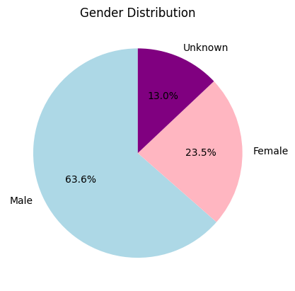

```python
# get counts of unique values in the 'Title' column, including NaN values
title_counts = demographic_info_df['Title'].value_counts(dropna=False)

# displaying the counts
print(title_counts)

# here we use a simple lambda function to infer gender
# if a value is not Mr or NaN, then set the gender to female, else set to male
demographic_info_df['Gender'] = demographic_info_df['Title'].apply(lambda x: 'Male' if x == 'Mr'else ('Female' if pd.notna(x) else 'Unknown'))


#import matplotlib for visualizations
import matplotlib.pyplot as plt

# Count occurrences of each gender
gender_counts = demographic_info_df['Gender'].value_counts()

# Create a pie chart
gender_counts.plot(kind='pie', autopct='%1.1f%%', colors=['lightblue', 'lightpink',"purple"], startangle=90)
plt.title('Gender Distribution')
plt.ylabel('')  # Remove the y-label for cleaner display
plt.show()
```

## Create bar chart of age distribtution

To do this I created a new column in the demographic dataset, I took user's date of birth and divided them into age categories of:

- 18-24
- 25-35
- 36-45
- 46-55
- 56-65
- 65+

From the resulting bar chart below, we can observe that the retailer's most common customers fall within the 25-35 and 36-45 age ranges. The least represented group consists of customers aged 65 and above, suggesting that the retailer may primarily target younger to middle-aged generations with potentially trendier fashion styles.

```
Empty DataFrame
Columns: [Customer ID, Title, Date Of Birth, Address City, Contact Allowed, Registration Date, Source of Customer, Gender]
Index: []
Number of rows with missing 'Date of Birth': 0
0
   Customer ID Date of Birth  Age Age Category
0            1    1973-06-29   40        36-45
1            2    1984-07-25   29        25-35
2            3    1991-05-01   22        18-24
3            4    1986-11-30   27        25-35
4            5    1991-10-02   22        18-24
```

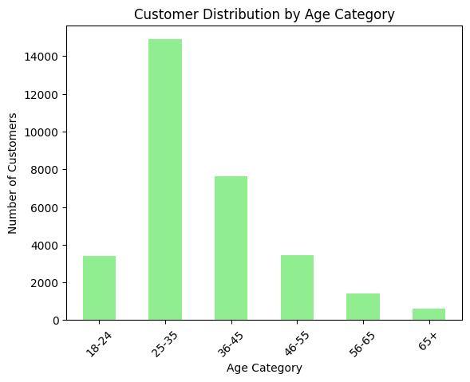

```python
# first we need to check for NA values in date of birth column

na_dob_rows = demographic_info_df[demographic_info_df['Date Of Birth'].isna()]

print(na_dob_rows)

# display the count of rows with NaN/NaT in 'Date of Birth'
print(f"Number of rows with missing 'Date of Birth': {len(na_dob_rows)}")


# package used for math calculations and data manipulation
import numpy as np

# Convert 'Date Of Birth' column to datetime, coerce invalid entries to NaT
demographic_info_df['Date of Birth'] = pd.to_datetime(demographic_info_df['Date Of Birth'], format='%d/%m/%Y', errors='coerce')

# Check for any NaT (Not a Time) values that failed conversion
print(demographic_info_df['Date of Birth'].isna().sum())

# Calculate age as of 2013 (since we're assuming it's still 2013)
demographic_info_df['Age'] = 2013 - demographic_info_df['Date of Birth'].dt.year

# Create age categories (bins)
age_bins = [18, 24, 35, 45, 55, 65, np.inf]  # Define the edges of the bins
age_labels = ['18-24', '25-35', '36-45', '46-55', '56-65', '65+']  # Labels for the bins

# Assign each customer to an age category
demographic_info_df['Age Category'] = pd.cut(demographic_info_df['Age'], bins=age_bins, labels=age_labels, right=False)

# Check the result
print(demographic_info_df[['Customer ID', 'Date of Birth', 'Age', 'Age Category']].head())

# Optional: Visualize the distribution of customers by age category
age_category_counts = demographic_info_df['Age Category'].value_counts().sort_index()

# Plot the age distribution as a bar chart
age_category_counts.plot(kind='bar', color='lightgreen')
plt.title('Customer Distribution by Age Category')
plt.xlabel('Age Category')
plt.ylabel('Number of Customers')
plt.xticks(rotation=45)
plt.show()
```

The above graph shows that most customers are between ages 25-35 and 36-45, suggesting the retailor should tailor mostly towards them

### Adding a Customer Loyalty Column

To gain deeper insights into the retailer's customer base, here I introduced a new column called "Loyalty." This column calculates the duration of each customer's registration with the retailer, measured in weeks. The loyalty period spans from each customer's registration date to June 30th, 2013, which we are treating as the current date.

I chose June 30th, 2013, as the cutoff date based on the available data definitions. According to these definitions, metrics such as Subsequent Orders and Subsequent Order Profit are calculated for the period up to June 30th, 2013. Therefore, aligning the loyalty calculation with this same timeframe ensures consistency in the analysis.

```python
# converting 'Registration Date' to datetime
demographic_info_df['Registration Date'] = pd.to_datetime(demographic_info_df['Registration Date'], dayfirst=True, errors='coerce')

# checking for any invalid dates dates couldn't be converted)
invalid_dates = demographic_info_df[demographic_info_df['Registration Date'].isna()]

# printing check
print("Invalid registration dates:")
print(invalid_dates)

# now, find the latest registration date
latest_registration_date = pd.to_datetime('2013-06-30')

# calculate loyalty in weeks as of the latest registration date
demographic_info_df['Loyalty (Weeks)'] = (latest_registration_date - demographic_info_df['Registration Date']).dt.days // 7

# sort the DataFrame by 'Registration Date' in ascending order
demographic_info_df_sorted = demographic_info_df.sort_values(by='Registration Date')

# Print the sorted DataFrame to check if date creation worked properly
print("\nFirst 5 rows sorted by Registration Date:")
print(demographic_info_df_sorted[['Customer ID', 'Registration Date', 'Loyalty (Weeks)']].head())

print("\nLast 5 rows sorted by Registration Date:")
print(demographic_info_df_sorted[['Customer ID', 'Registration Date', 'Loyalty (Weeks)']].tail())
```

```
Invalid registration dates:
Empty DataFrame
Columns: [Customer ID, Title, Date Of Birth, Address City, Contact Allowed, Registration Date, Source of Customer, Gender, Date of Birth, Age, Age Category]
Index: []

First 5 rows sorted by Registration Date:
   Customer ID   Registration Date  Loyalty (Weeks)
0            1 2013-01-01 00:23:00               25
1            2 2013-01-01 00:30:00               25
2            3 2013-01-01 01:09:00               25
3            4 2013-01-01 01:19:00               25
4            5 2013-01-01 01:58:00               25

Last 5 rows sorted by Registration Date:
       Customer ID   Registration Date  Loyalty (Weeks)
24079        24080 2013-03-31 23:07:00               12
24080        24081 2013-03-31 23:16:00               12
24081        24082 2013-03-31 23:32:00               12
24082        24083 2013-03-31 23:39:00               12
24083        24084 2013-03-31 23:52:00               12
```

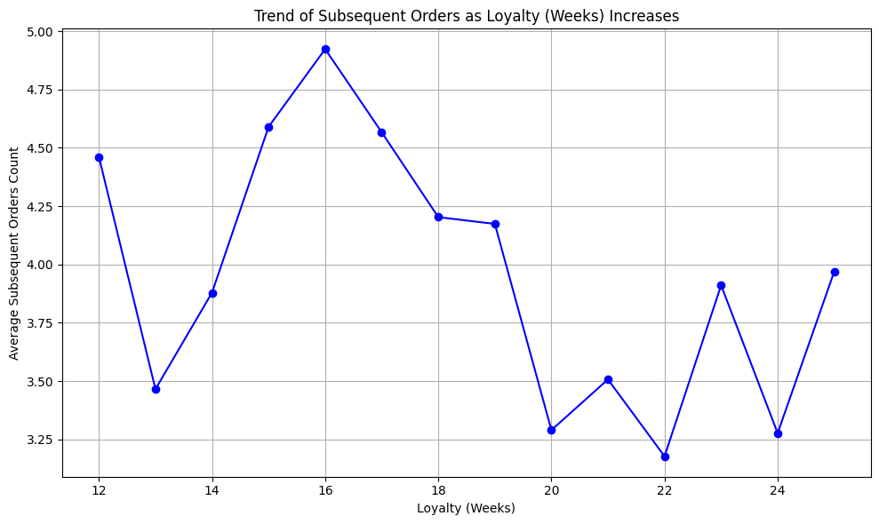

```python
import pandas as pd
import matplotlib.pyplot as plt

# Step 1: Merge the demographic and value info DataFrames on 'Customer ID'
merged_df = pd.merge(demographic_info_df[['Customer ID', 'Loyalty (Weeks)']], value_info_df[['Customer ID', 'Subsequent Orders Count']], on='Customer ID')

# Step 2: Group the merged data by 'Loyalty (Weeks)' and calculate the average 'Subsequent Orders Count'
loyalty_order_trend = merged_df.groupby('Loyalty (Weeks)')['Subsequent Orders Count'].mean().reset_index()

# Step 3: Plot the time series to visualize the trend
plt.figure(figsize=(10, 6))
plt.plot(loyalty_order_trend['Loyalty (Weeks)'], loyalty_order_trend['Subsequent Orders Count'], marker='o', color='blue')

# Add labels and title
plt.title('Trend of Subsequent Orders as Loyalty (Weeks) Increases')
plt.xlabel('Loyalty (Weeks)')
plt.ylabel('Average Subsequent Orders Count')
plt.grid(True)
plt.tight_layout()

# Show the plot
plt.show()
```

### Determining the Percentage of Contactable Customers

This analysis will help evaluate whether being able to contact customers influences the likelihood of repeat purchases or subsequent orders.

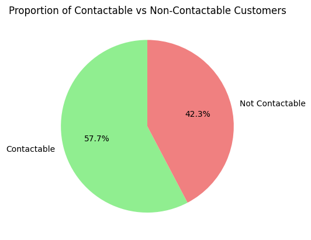

```python
### Again, to build a better picture of customers, here I observe what proprotion of customers are and aren't contactable


# Count the number of customers who are and aren't contactable
contact_counts = demographic_info_df['Contact Allowed'].value_counts()

# Create a pie chart
contact_counts.plot(kind='pie', autopct='%1.1f%%', colors=['lightgreen', 'lightcoral'], startangle=90, labels=['Contactable', 'Not Contactable'])

# Add a title
plt.title('Proportion of Contactable vs Non-Contactable Customers')

# Remove the y-label for cleaner display
plt.ylabel('')

# Display the pie chart
plt.show()
```

```python
# Merge the two DataFrames on 'Customer ID'
merged_df = pd.merge(demographic_info_df, value_info_df[['Customer ID', 'Subsequent Orders Count']], on='Customer ID', how='left')

# Create a new column 'Repeat Purchaser' based on whether 'Subsequent Orders Count' is greater than 0
merged_df['Repeat Purchaser'] = merged_df['Subsequent Orders Count'] > 0

# Check the result (first few rows)
print(merged_df[['Customer ID', 'Subsequent Orders Count', 'Repeat Purchaser']].head())

# Add the 'Repeat Purchaser' column back to the original demographic_info_df
demographic_info_df['Repeat Purchaser'] = merged_df['Repeat Purchaser']

# Check the updated demographic_info_df (first few rows)
print(demographic_info_df.head())
```

```
   Customer ID  Subsequent Orders Count  Repeat Purchaser
0            1                      1.0              True
1            2                      7.0              True
2            3                      7.0              True
3            4                      0.0             False
4            5                      9.0              True
   Customer ID Title Date Of Birth Address City Contact Allowed  \
0            1    Mr    29/06/1973     Malahide               Y
1            2    Mr    25/07/1984       Dublin               Y
2            3    Mr    01/05/1991       Dublin               Y
3            4    Mr    30/11/1986       Dublin               N
4            5    Mr    02/10/1991     Limerick               Y

    Registration Date Source of Customer Gender Date of Birth  Age  \
0 2013-01-01 00:23:00     Organic Search   Male    1973-06-29   40
1 2013-01-01 00:30:00         Affiliates   Male    1984-07-25   29
2 2013-01-01 01:09:00        Paid Social   Male    1991-05-01   22
3 2013-01-01 01:19:00         Affiliates   Male    1986-11-30   27
4 2013-01-01 01:58:00        Paid Search   Male    1991-10-02   22

  Age Category  Loyalty (Weeks)  Repeat Purchaser
0        36-45               25              True
1        25-35               25              True
2        18-24               25              True
3        25-35               25             False
4        18-24               25              True
```

[figure not shown]

```python
import matplotlib.pyplot as plt

# Count the number of repeat and non-repeat purchasers
repeat_counts = demographic_info_df['Repeat Purchaser'].value_counts()

# Create a pie chart
repeat_counts.plot(kind='pie', autopct='%1.1f%%', colors=['lightblue', 'lightcoral'], startangle=90, labels=['Non-Repeat Purchasers', 'Repeat Purchasers'])

# Add a title
plt.title('Proportion of Repeat vs Non-Repeat Purchasers')

# Remove the y-label for cleaner display
plt.ylabel('')

# Show the pie chart
plt.show()
```

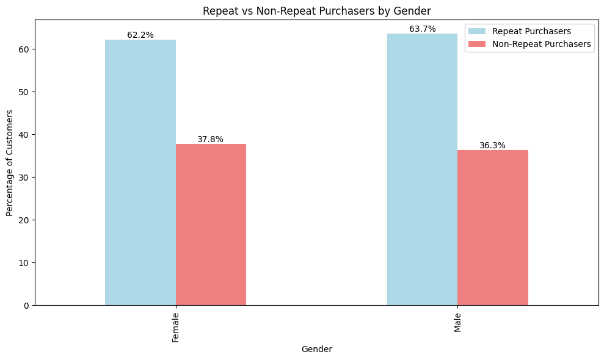

```python
# Filter out 'Unknown' gender
filtered_gender_df = demographic_info_df[demographic_info_df['Gender'] != 'Unknown']

# Calculate repeat and non-repeat purchasers by Gender
repeat_by_gender = filtered_gender_df.groupby('Gender')['Repeat Purchaser'].mean() * 100
non_repeat_by_gender = 100 - repeat_by_gender  # Non-repeat is 100% minus repeat percentage

# Combine the data into a new DataFrame
repeat_data = pd.DataFrame({
    'Repeat Purchasers': repeat_by_gender,
    'Non-Repeat Purchasers': non_repeat_by_gender
})

# Plotting the dual bar chart with a wider figure
fig, ax = plt.subplots(figsize=(10, 6))  # Adjusted the width (10) to make the graph wider
repeat_data.plot(kind='bar', stacked=False, color=['lightblue', 'lightcoral'], ax=ax)

# Add percentage labels on the bars
for container in ax.containers:
    ax.bar_label(container, fmt='%.1f%%')

# Customize the plot
plt.title('Repeat vs Non-Repeat Purchasers by Gender')
plt.xlabel('Gender')
plt.ylabel('Percentage of Customers')
plt.tight_layout()
plt.show()
```

The above graph shows that doesn't play a significant role in the number of repeat customers, only differing by less than 2%

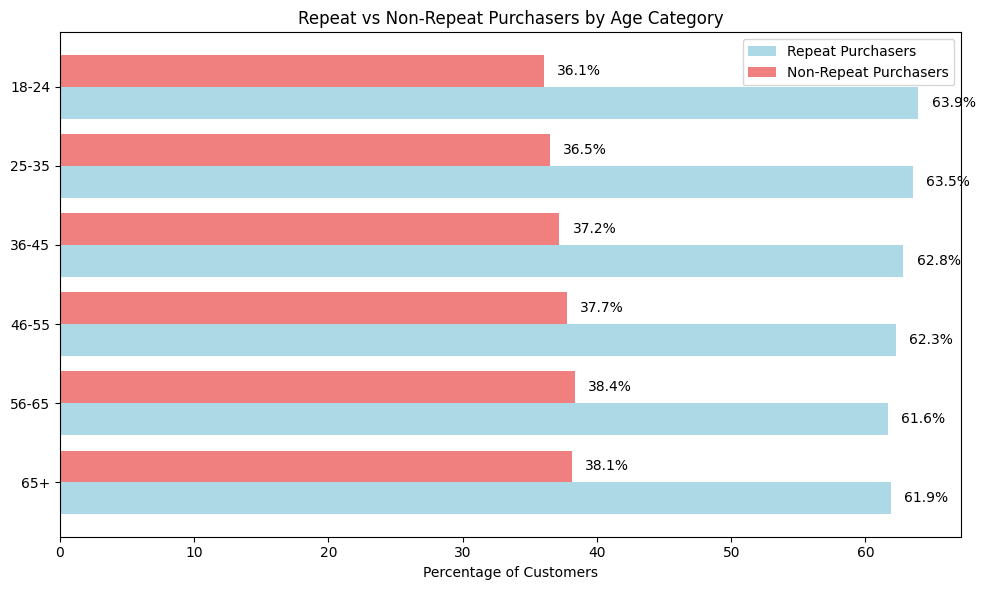

```python
# Get unique age categories in sorted order
age_categories = sorted(demographic_info_df['Age Category'].dropna().unique(), reverse = True)  # Sort the age categories

# Create a list to store percentages of repeat and non-repeat purchasers for each age group
repeat_purchasers = []
non_repeat_purchasers = []

# Loop through each age category and calculate percentages
for age_group in age_categories:
    # Filter the data for the current age group
    filtered_age_df = demographic_info_df[demographic_info_df['Age Category'] == age_group]

    # Calculate repeat and non-repeat purchasers for this age group
    repeat_percentage = filtered_age_df['Repeat Purchaser'].mean() * 100
    non_repeat_percentage = 100 - repeat_percentage

    # Append the values to the lists
    repeat_purchasers.append(repeat_percentage)
    non_repeat_purchasers.append(non_repeat_percentage)

# Set up the bar positions and width
bar_width = 0.4
r1 = range(len(age_categories))  # Positions for repeat purchasers
r2 = [x + bar_width for x in r1]  # Positions for non-repeat purchasers

# Create the bar chart
fig, ax = plt.subplots(figsize=(10, 6))

# Plot repeat and non-repeat purchasers side by side
ax.barh(r1, repeat_purchasers, height=bar_width, color='lightblue', label='Repeat Purchasers')
ax.barh(r2, non_repeat_purchasers, height=bar_width, color='lightcoral', label='Non-Repeat Purchasers')

# Add labels to the bars
for i in range(len(r1)):
    ax.text(repeat_purchasers[i] + 1, r1[i], f'{repeat_purchasers[i]:.1f}%', va='center', color='black')
    ax.text(non_repeat_purchasers[i] + 1, r2[i], f'{non_repeat_purchasers[i]:.1f}%', va='center', color='black')

# Customize the plot
ax.set_yticks([r + bar_width / 2 for r in range(len(age_categories))])  # Center the ticks between bars
ax.set_yticklabels(age_categories)  # Set the age categories in ascending order
ax.set_xlabel('Percentage of Customers')
ax.set_title('Repeat vs Non-Repeat Purchasers by Age Category')
ax.legend()

# Adjust layout and show the plot
plt.tight_layout()
plt.show()
```

The above graph reveals minimal differences across age categories. However, it is noteworthy that as customers age, they become slightly less likely to make another purchase within a 3-month period. This difference is only 2%, making it not particularly significant.

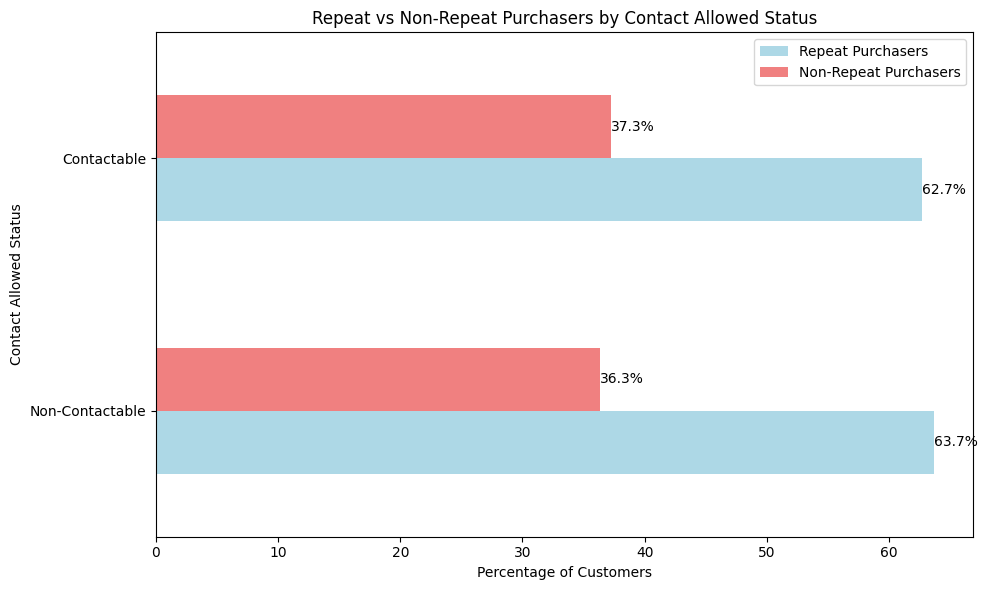

```python
import pandas as pd
import matplotlib.pyplot as plt

# Calculate repeat and non-repeat purchasers for contactable vs non-contactable customers
repeat_by_contact = demographic_info_df.groupby('Contact Allowed')['Repeat Purchaser'].mean() * 100
non_repeat_by_contact = 100 - repeat_by_contact  # Non-repeat is 100% minus repeat percentage

# Combine the data into a new DataFrame
contact_data = pd.DataFrame({
    'Repeat Purchasers': repeat_by_contact,
    'Non-Repeat Purchasers': non_repeat_by_contact
})

# Plotting the dual bar chart
fig, ax = plt.subplots(figsize=(10, 6))

# Plot repeat and non-repeat purchasers side by side
contact_data.plot(kind='barh', stacked=False, color=['lightblue', 'lightcoral'], ax=ax)

# Add percentage labels on the bars
for container in ax.containers:
    ax.bar_label(container, fmt='%.1f%%')

# Customize the plot
plt.title('Repeat vs Non-Repeat Purchasers by Contact Allowed Status')
plt.xlabel('Percentage of Customers')
plt.ylabel('Contact Allowed Status')
ax.set_yticklabels(['Non-Contactable', 'Contactable'])  # Customize the y-tick labels
plt.tight_layout()

# Show the plot
plt.show()
```

Interestingly, the graph shows little difference in repeat customer rates between contactable and non-contactable customers, with only about a one percent variation.

### Creating a bar chart of the source of customers

However, while this chart provides insight into the volume of customers from each source, it doesn't necessarily indicate which channels are the most profitable or attract the most loyal customers. It also lacks demographic insights, which could help us understand the types of customers each channel brings in.

In the following analysis, we will delve deeper into customer behavior, profitability, and loyalty across these sources, along with demographic breakdowns, to provide a more comprehensive view.

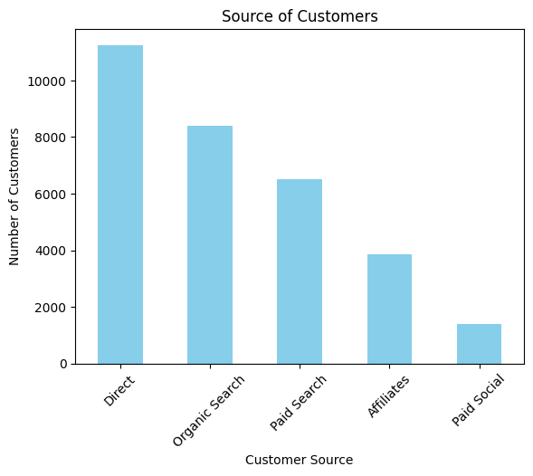

```python
# plotting the source of customers as a bar chart
source_counts = demographic_info_df['Source of Customer'].value_counts()

# creating a bar chart
source_counts.plot(kind='bar', color='skyblue')
plt.title('Source of Customers')
plt.xlabel('Customer Source')
plt.ylabel('Number of Customers')
plt.xticks(rotation=45)
plt.show()
```

# One more thing before main analysis

During our initial observations we found that not all customer IDs that exist in the **Demographic Info** dataframe also exist in the **Value Info** dataframe. For this reason we need to remove rows form the **Demographic Info** dataframe where their customer ID doesn't exist in the **Value info** dataframe. We do this as the analysis is based around profit, so therefore we only want records of users that can be linked to the quantitative data

```python
# checking current length
print(len(demographic_info_df))
```

```
31441
```

```python
# Using an inner merge to only keep matching Customer IDs
filtered_demographic_info_df = pd.merge(demographic_info_df, value_info_df[['Customer ID']], on='Customer ID', how='inner')
# Check if the filtered demographic_info_df contains only matching Customer IDs
print(filtered_demographic_info_df.head())
```

```
   Customer ID Title Date Of Birth Address City Contact Allowed  \
0            1    Mr    29/06/1973     Malahide               Y
1            2    Mr    25/07/1984       Dublin               Y
2            3    Mr    01/05/1991       Dublin               Y
3            4    Mr    30/11/1986       Dublin               N
4            5    Mr    02/10/1991     Limerick               Y

    Registration Date Source of Customer Gender Date of Birth  Age  \
0 2013-01-01 00:23:00     Organic Search   Male    1973-06-29   40
1 2013-01-01 00:30:00         Affiliates   Male    1984-07-25   29
2 2013-01-01 01:09:00        Paid Social   Male    1991-05-01   22
3 2013-01-01 01:19:00         Affiliates   Male    1986-11-30   27
4 2013-01-01 01:58:00        Paid Search   Male    1991-10-02   22

  Age Category  Loyalty (Weeks)  Repeat Purchaser
0        36-45               25              True
1        25-35               25              True
2        18-24               25              True
3        25-35               25             False
4        18-24               25              True
```

```python
# confirm customer ids have been removed
print(len(filtered_demographic_info_df))
```

```
30591
```

```python
demographic_info_df = filtered_demographic_info_df.copy()
```

# **Analysis**

In this section, I examined key aspects of the dataset to uncover insights related to customer behavior, marketing performance, and profitability. The age and gender categories identified during the initial exploration and data cleaning were incorporated into this analysis, though demographic findings proved to be less impactful than anticipated. Below is an outline of the key subsections in this Analysis:

Key Objectives:

**Update Cost Table:**

- As mentioned previously in the observations section, there were missing details in the cost table, I also didn't know exactly what the numeric values represent, whether they represented total sales with promotion deduciton or total sales without promotions deduction. In the end I wasn't able to figure it out so ended up just recreating the table to show total profit by month including promotions, using the value info dataset

**Customer Acquisition by Demographics:**

Here I analyzed which marketing channels (e.g., Affiliates, Paid Search, Paid Social) acquire the most customers, broken down by:

- Age Category (e.g., 18-24, 25-35, etc.).
- Gender (e.g., Male, Female).

**Repeat Purchase Behavior by Channel:**

- Investigating whether customers who have allowed contact (i.e., are contactable) are more or less likely to make repeat purchases compared to non-contactable customers.
- Examining which marketing channels are most effective at acquiring repeat purchasers.

**Profitability by Channel:**

I Analyze the most profitable channels based on:

- 1st Order Profit and Subsequent Order Profit data.
- Identifying which marketing channels bring in the highest profits from customers.
- Identifying which channels come with highest promotion/ discount usage

**Forecast of Average Profit per Customers using Repeat Purchaser Rates**

- Finally, I carried out a forecast of the **average sales** per customer after 2 years for each marketing channel source, using the rates of repeat purchasers from the Subsequent Orders Count column
- Additionally, I conducted a 2-year forecast of **total profits** for each marketing channel, first using their original acquisition rates, and then applying a uniform growth rate across all channels, matching the rate of Direct. I selected Direct’s rate as a variable because it has the highest acquisition rate, and I wanted to demonstrate that if other channels achieved the same acquisition rate as Direct, they could potentially be more profitable

## **Update Cost Table**

```python
pd.set_option('display.max_columns', False)

# Step 1: Merge demographic_info_df with value_info_df on 'Customer ID'
merged_df = pd.merge(demographic_info_df, value_info_df, on='Customer ID', how='inner')

# Step 2: Calculate the total profit for each customer without promotions deduction
merged_df['Total Profit Without Promotions'] = merged_df['1st Order Profit'] + merged_df['Subsequent Order Profit'] - merged_df["Total value of all promotions"]

# Step 3: Convert 'Registration Date' to datetime format and extract the month and year
merged_df['Registration Date'] = pd.to_datetime(merged_df['Registration Date'], dayfirst=True)
merged_df['Month-Year'] = merged_df['Registration Date'].dt.to_period('M')  # To ensure proper sorting by month

# Step 4: Group by 'Month-Year' and 'Source of Customer' to calculate total profit (without promotions) for each month and source
monthly_profit_by_source_without_promotions = merged_df.groupby(['Month-Year', 'Source of Customer'])['Total Profit Without Promotions'].sum().reset_index()

# Step 5: Pivot the table to make 'Month-Year' the index and 'Source of Customer' the columns
profit_pivot_table_without_promotions = monthly_profit_by_source_without_promotions.pivot(index='Month-Year', columns='Source of Customer', values='Total Profit Without Promotions')

# Step 6: Sort the pivot table by the 'Month-Year' index to ensure correct chronological order
profit_pivot_table_without_promotions = profit_pivot_table_without_promotions.sort_index()

# Step 7: Display the result
print(profit_pivot_table_without_promotions)
```

```
Source of Customer  Affiliates  Direct  Organic Search  Paid Search  Paid Social
Month-Year
2013-01                  22441  103169           65923        57745        11565
2013-02                  21582  145237           84353       110895        12948
2013-03                  69519  216577          203055        97559        51672
```

The figures above do not match the figures in the original cost data provided below. I am not sure why this is. However, we will ignore this for the rest of the analysis, and continue with our own data from the original value info dataframe.

[figure not shown]

Below I later use this newly updated cost table in time series plots to illustrate the monthly trends and the direction of the slope for each channel.

## Customer Acquisition by Demographics

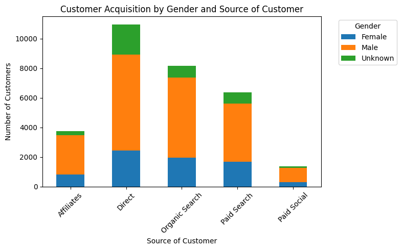

```python
# create dataframe to display data
acquisition_by_gender = demographic_info_df.groupby(['Source of Customer', 'Gender']).size().unstack()

# Plot the results as a bar chart
acquisition_by_gender.plot(kind='bar', stacked=True, figsize=(8, 5))
plt.title('Customer Acquisition by Gender and Source of Customer')
plt.xlabel('Source of Customer')
plt.ylabel('Number of Customers')
plt.xticks(rotation=45)
plt.legend(title='Gender', bbox_to_anchor=(1.05, 1), loc='upper left')
plt.tight_layout()
plt.show()
```

Stacked bar isn't so information so let's try another, this time displaying percentages instead of counts

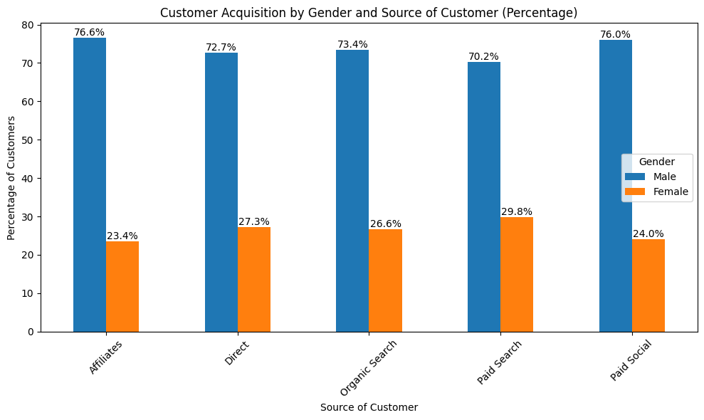

```python
# filter out 'Unknown' gender
acquisition_by_gender_filtered = demographic_info_df[demographic_info_df['Gender'].isin(['Male', 'Female'])]

# group by Source of Customer and Gender
acquisition_by_gender = acquisition_by_gender_filtered.groupby(['Source of Customer', 'Gender']).size().unstack()

# calculate the percentage for each gender in each channel
acquisition_by_gender_percentage = acquisition_by_gender.div(acquisition_by_gender.sum(axis=1), axis=0) * 100

# plot the results as a dual bar chart (side by side bars for Male and Female)
ax = acquisition_by_gender_percentage[['Male', 'Female']].plot(kind='bar', figsize=(10, 6))

# Adding percentage labels on each bar
for container in ax.containers:
    ax.bar_label(container, fmt='%.1f%%', label_type='edge')

# plot chart
plt.title('Customer Acquisition by Gender and Source of Customer (Percentage)')
plt.xlabel('Source of Customer')
plt.ylabel('Percentage of Customers')
plt.xticks(rotation=45)
plt.legend(title='Gender')
plt.tight_layout()

plt.show()
```

**Key Insights of Above Graph**

- Data doesn't vary significatnly (**6%**)
- Affiliates has the highest acquisition rates for men
- Paid Search has the highest acquiistion rate for women

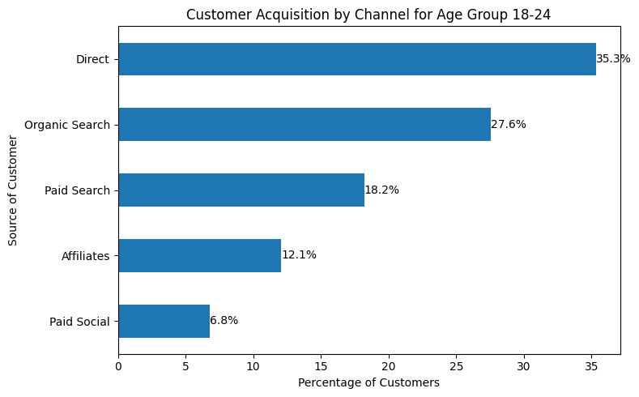

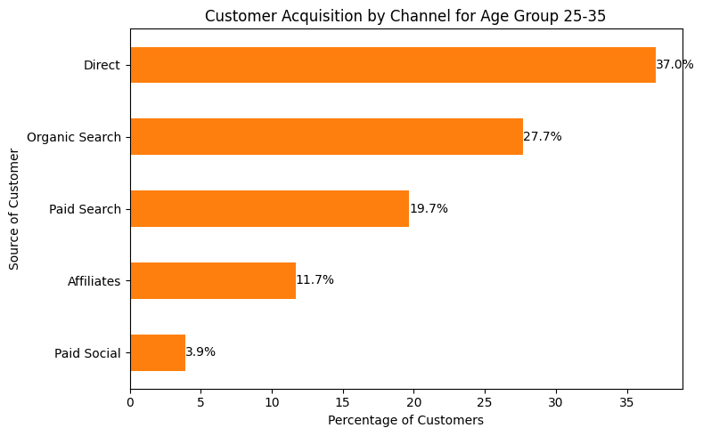

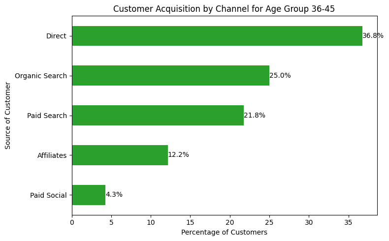

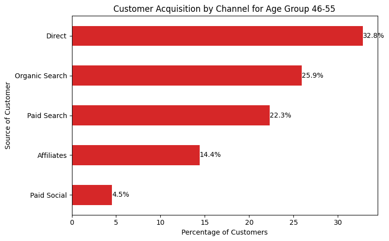

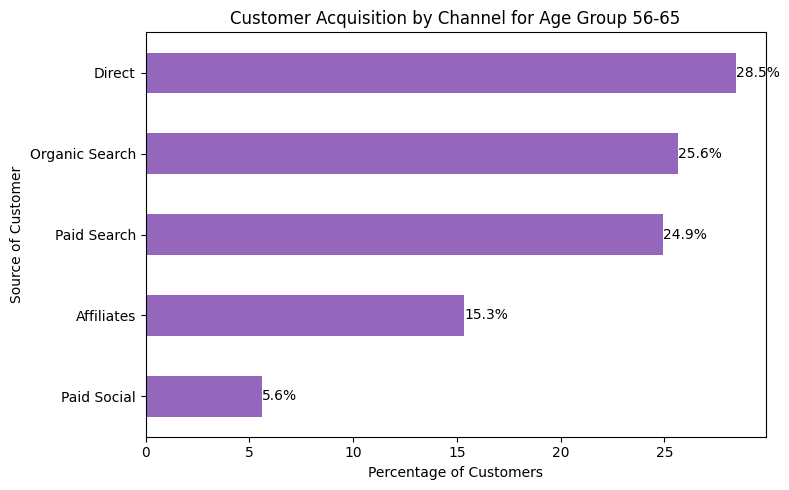

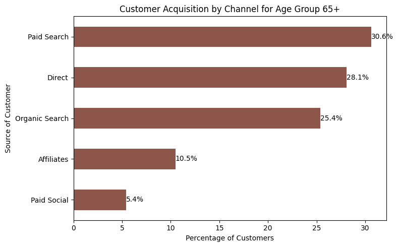

```python
import matplotlib.pyplot as plt

# List of unique age categories in the dataset, sorted to ensure they appear in order
age_categories = sorted(demographic_info_df['Age Category'].dropna().unique())

# Define colors for each age group
colors = ['#1f77b4', '#ff7f0e', '#2ca02c', '#d62728', '#9467bd', '#8c564b']  # Custom colors for each group

# Loop through each age category and create a bar chart
for i, age_group in enumerate(age_categories):
    # Filter the data for the current age group
    age_group_df = demographic_info_df[demographic_info_df['Age Category'] == age_group]

    # Group by 'Source of Customer' and calculate the count for each channel
    channel_counts = age_group_df['Source of Customer'].value_counts()

    # Calculate percentages for each channel
    channel_percentages = (channel_counts / channel_counts.sum()) * 100

    # Sort the channels by percentage in ascending order
    channel_percentages = channel_percentages.sort_values(ascending=True)

    # Plot the bar chart with a specific color for this age group
    ax = channel_percentages.plot(kind='barh', figsize=(8, 5), color=colors[i])

    # Add percentage labels on each bar
    for container in ax.containers:
        ax.bar_label(container, fmt='%.1f%%', label_type='edge')

    # Add chart title and labels
    plt.title(f'Customer Acquisition by Channel for Age Group {age_group}')
    plt.xlabel('Percentage of Customers')
    plt.ylabel('Source of Customer')

    # Display the plot
    plt.tight_layout()
    plt.show()
```

**Key Insights for Gender:**

- **Paid Search** tends to attract more **female** customers (29.8%) compared to other channels.
- **Affiliates** and **Paid Social** are more effective at acquiring **male customers** (over 76% male).
- The **percentage differences between genders** across all channels are relatively small (around 6% variation), suggesting that these insights may not be highly significant. However, it's still worth considering. Since **Paid Social** and **Affiliates** were the weakest overall performers, a possible improvement could be to **reduce the proportion of these links shown to female customers**, given that they are more popular with male customers. This adjustment might help improve their performance.

**Key Insights for Age:**

- Marketing channel effectiveness did not vary significantly by age category.
- **Direct** and **Organic Search** were the most popular channels across all age groups, with Paid Search typically being the third most popular. **Affiliates** and **Paid Social** consistently underperformed. Comparing these insights with earlier exploration, we can conclude that these channel acquisition patterns do not change with age category.
- The only exception was with the **65+** age category, where **Paid Search** became the most acquisitive channel. Targeting users in this age group with **Paid Search** links (users who sign up through paid Google advertising) would likely yield the most benefit.

#### **Repeat Purchase Behavior by Channel**:

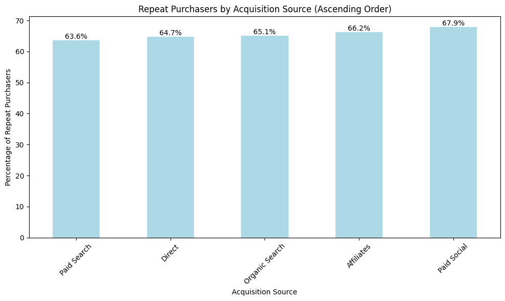

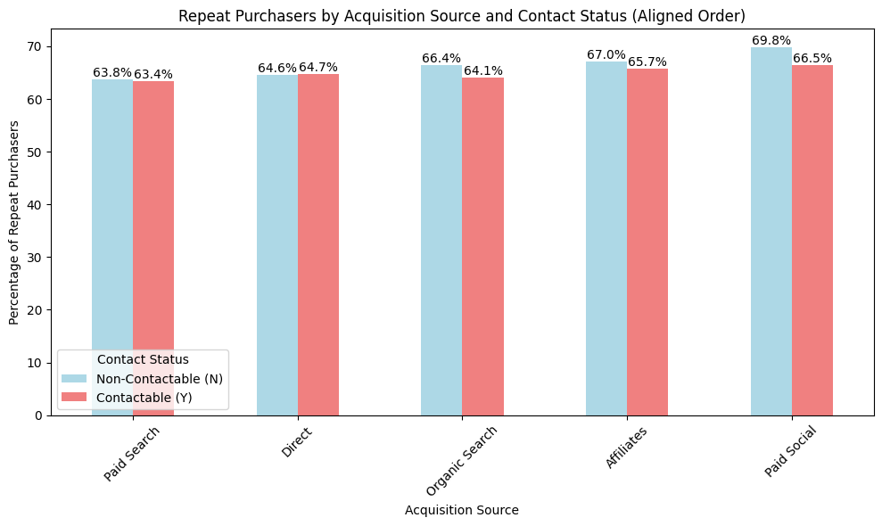

```python
import pandas as pd
import matplotlib.pyplot as plt

# Step 1: Calculate repeat purchase percentage by acquisition source and sort in ascending order
repeat_by_source = demographic_info_df.groupby('Source of Customer')['Repeat Purchaser'].mean() * 100
repeat_by_source = repeat_by_source.sort_values(ascending=True)  # Sort in ascending order

# Plot the repeat purchase percentage by acquisition source with percentages
fig, ax = plt.subplots(figsize=(10, 6))
bars = repeat_by_source.plot(kind='bar', color='lightblue', ax=ax)

# Add percentage labels on each bar
for container in ax.containers:
    ax.bar_label(container, fmt='%.1f%%')

# Customize the plot
plt.title('Repeat Purchasers by Acquisition Source (Ascending Order)')
plt.xlabel('Acquisition Source')
plt.ylabel('Percentage of Repeat Purchasers')
plt.xticks(rotation=45)
plt.tight_layout()
plt.show()

# Step 2: Check repeat purchase behavior by contact status within each acquisition source
# Group by 'Source of Customer' and 'Contact Allowed' (Y/N), then calculate repeat purchase percentage
repeat_by_source_and_contact = demographic_info_df.groupby(['Source of Customer', 'Contact Allowed'])['Repeat Purchaser'].mean() * 100

# Unstack the data so we can plot contactable (Y) vs non-contactable (N) side by side
repeat_by_source_and_contact = repeat_by_source_and_contact.unstack()

# Ensure the second chart is ordered in the same way as the first chart by reordering the acquisition sources
repeat_by_source_and_contact = repeat_by_source_and_contact.loc[repeat_by_source.index]  # Align with the order of the first chart

# Plot the results with percentage labels
fig, ax = plt.subplots(figsize=(10, 6))
bars = repeat_by_source_and_contact.plot(kind='bar', stacked=False, ax=ax, color=['lightblue', 'lightcoral'])

# Add percentage labels on each bar
for container in ax.containers:
    ax.bar_label(container, fmt='%.1f%%')

# Customize the plot
plt.title('Repeat Purchasers by Acquisition Source and Contact Status (Aligned Order)')
plt.xlabel('Acquisition Source')
plt.ylabel('Percentage of Repeat Purchasers')
plt.xticks(rotation=45)
plt.legend(title='Contact Status', labels=['Non-Contactable (N)', 'Contactable (Y)'])
plt.tight_layout()
plt.show()
```

The above graphs only use true or false values from the demographic info dataset, now let's look at the number of repeat purchases using the **Subsequent Orders Count** column from the value info dataset

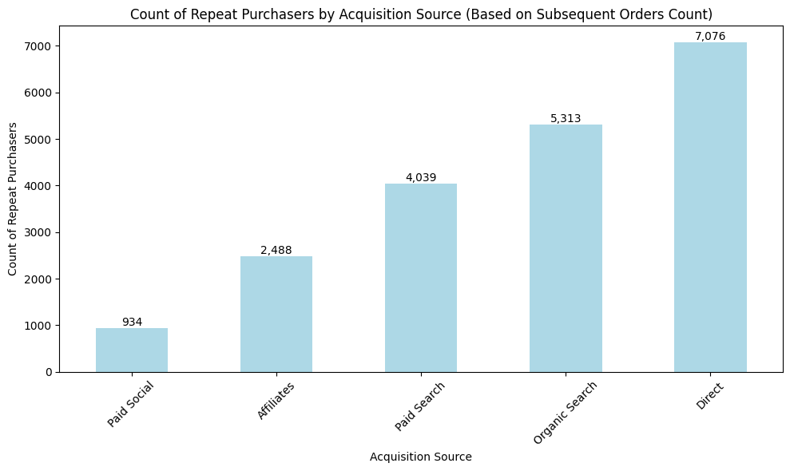

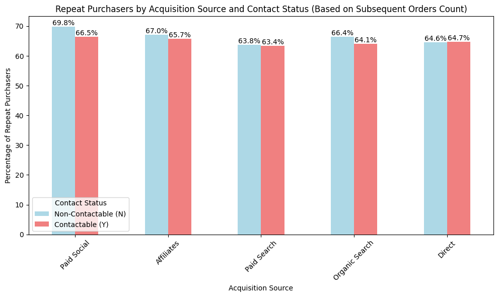

```python
import pandas as pd
import matplotlib.pyplot as plt

# Step 1: Merge demographic_info_df with value_info_df on 'Customer ID'
merged_df = pd.merge(demographic_info_df, value_info_df, on='Customer ID', how='inner')

# Step 2: Create a new column indicating whether a customer is a repeat purchaser (Subsequent Orders Count > 0)
merged_df['Repeat Purchaser'] = merged_df['Subsequent Orders Count'] > 0

# Step 3: Calculate repeat purchase count by acquisition source (count of repeat purchasers)
repeat_by_source_count = merged_df[merged_df['Repeat Purchaser']].groupby('Source of Customer').size()

# Plot the repeat purchase count by acquisition source
fig, ax = plt.subplots(figsize=(10, 6))
repeat_by_source_count = repeat_by_source_count.sort_values(ascending=True)  # Sort in ascending order
bars = repeat_by_source_count.plot(kind='bar', color='lightblue', ax=ax)

# Add formatted count labels on each bar (formatted as "0,000")
for container in ax.containers:
    ax.bar_label(container, fmt='{:,.0f}')

# Customize the plot
plt.title('Count of Repeat Purchasers by Acquisition Source (Based on Subsequent Orders Count)')
plt.xlabel('Acquisition Source')
plt.ylabel('Count of Repeat Purchasers')
plt.xticks(rotation=45)
plt.tight_layout()
plt.show()

# Step 4: Check repeat purchase behavior by contact status within each acquisition source
repeat_by_source_and_contact = merged_df.groupby(['Source of Customer', 'Contact Allowed'])['Repeat Purchaser'].mean() * 100

# Unstack the data so we can plot contactable (Y) vs non-contactable (N) side by side
repeat_by_source_and_contact = repeat_by_source_and_contact.unstack()

# Ensure the second chart is ordered in the same way as the first chart by reordering the acquisition sources
repeat_by_source_and_contact = repeat_by_source_and_contact.loc[repeat_by_source_count.index]  # Align with the order of the first chart

# Plot the results with percentage labels
fig, ax = plt.subplots(figsize=(10, 6))
bars = repeat_by_source_and_contact.plot(kind='bar', stacked=False, ax=ax, color=['lightblue', 'lightcoral'])

# Add percentage labels on each bar
for container in ax.containers:
    ax.bar_label(container, fmt='%.1f%%')

# Customize the plot
plt.title('Repeat Purchasers by Acquisition Source and Contact Status (Based on Subsequent Orders Count)')
plt.xlabel('Acquisition Source')
plt.ylabel('Percentage of Repeat Purchasers')
plt.xticks(rotation=45)
plt.legend(title='Contact Status', labels=['Non-Contactable (N)', 'Contactable (Y)'])
plt.tight_layout()
plt.show()
```

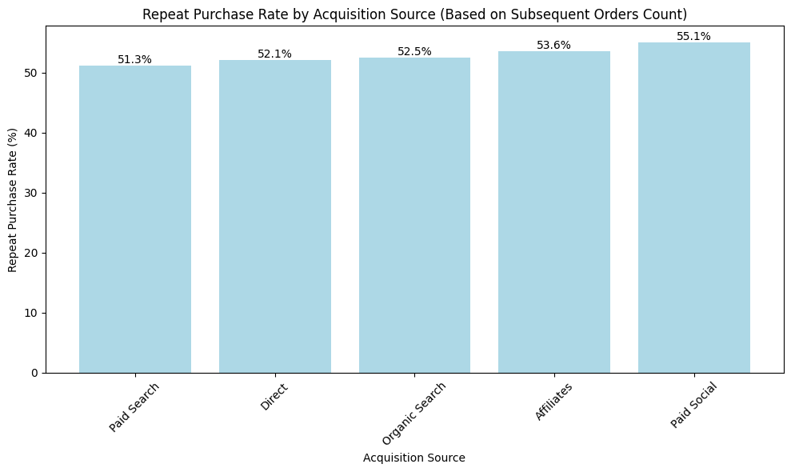

```python
import pandas as pd
import matplotlib.pyplot as plt

# Step 1: Merge demographic_info_df with value_info_df on 'Customer ID'
merged_df = pd.merge(demographic_info_df, value_info_df, on='Customer ID', how='inner')

# Step 2: Create a new column indicating the repeat purchase rate (Subsequent Orders Count / Total Orders)
# We assume that the total orders are 1st Order + Subsequent Orders Count
merged_df['Repeat Purchase Rate'] = merged_df['Subsequent Orders Count'] / (merged_df['Subsequent Orders Count'] + 1)

# Step 3: Group by 'Source of Customer' to calculate the average repeat purchase rate for each channel
repeat_purchase_rate_by_source = merged_df.groupby('Source of Customer')['Repeat Purchase Rate'].mean().reset_index()

# Step 4: Sort the repeat purchase rate data in ascending order
repeat_purchase_rate_by_source = repeat_purchase_rate_by_source.sort_values(by='Repeat Purchase Rate', ascending=True)

# Step 5: Plot the repeat purchase rate by acquisition source
plt.figure(figsize=(10, 6))
bars = plt.bar(repeat_purchase_rate_by_source['Source of Customer'], repeat_purchase_rate_by_source['Repeat Purchase Rate'] * 100, color='lightblue')

# Add percentage labels on bars
for bar in bars:
    height = bar.get_height()
    plt.text(bar.get_x() + bar.get_width()/2.0, height, f'{height:.1f}%', ha='center', va='bottom')

# Customize the plot
plt.title('Repeat Purchase Rate by Acquisition Source (Based on Subsequent Orders Count)')
plt.xlabel('Acquisition Source')
plt.ylabel('Repeat Purchase Rate (%)')
plt.xticks(rotation=45)
plt.tight_layout()
plt.show()
```

**Key Insights:**

- Direct has the highest count of subsequent orders, making it the most profitable channel due to its larger customer base and high acquisition rate.
- However, both Paid Social and Affiliates show higher percentage rates of repeat purchasers despite lower overall acquisition rates. This indicates that customers acquired through these channels are more likely to become repeat purchasers. If the retailer could increase the acquisition rates for Paid Social and Affiliates, these channels could become more profitable due to the higher loyalty and repeat purchase behavior of customers acquired through them.
- This suggests a potential strategy to balance between the high volume of Direct customers and the high loyalty seen in Paid Social and Affiliates, optimizing profitability across all channels.

## **Profitability by Channel**

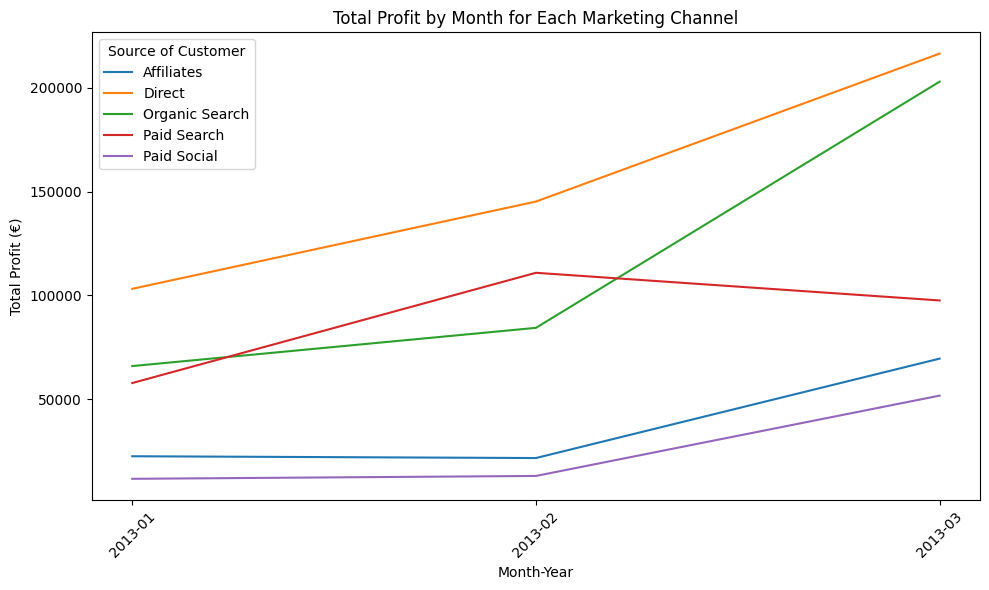

```python
# Step 1: Ensure 'Registration Date' is in datetime format and extract 'Month-Year'
merged_df['Registration Date'] = pd.to_datetime(merged_df['Registration Date'], dayfirst=True)
merged_df['Month-Year'] = merged_df['Registration Date'].dt.to_period('M')  # To ensure proper sorting by month

# Step 2: Calculate total profit for each customer (1st Order Profit + Subsequent Order Profit)
merged_df['Total Profit'] = merged_df['1st Order Profit'] + merged_df['Subsequent Order Profit'] - merged_df["Total value of all promotions"]

# Step 3: Group by 'Month-Year' and 'Source of Customer' to calculate total profit by month and channel
monthly_profit_by_channel = merged_df.groupby(['Month-Year', 'Source of Customer'])['Total Profit'].sum().unstack()

# Step 4: Plot time series of total profit by month for each marketing channel
plt.figure(figsize=(10, 6))
for column in monthly_profit_by_channel.columns:
    plt.plot(monthly_profit_by_channel.index.astype(str), monthly_profit_by_channel[column], label=column)

# Customize the plot
plt.title('Total Profit by Month for Each Marketing Channel')
plt.xlabel('Month-Year')
plt.ylabel('Total Profit (€)')
plt.xticks(rotation=45)
plt.legend(title='Source of Customer')
plt.tight_layout()
plt.show()
```

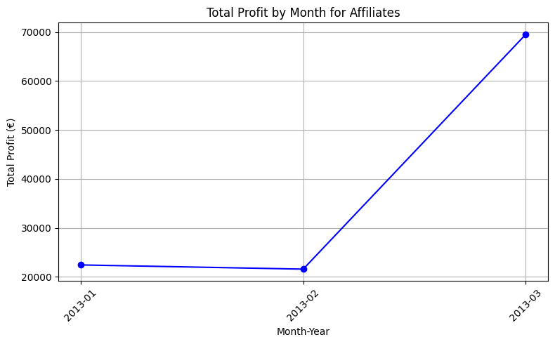

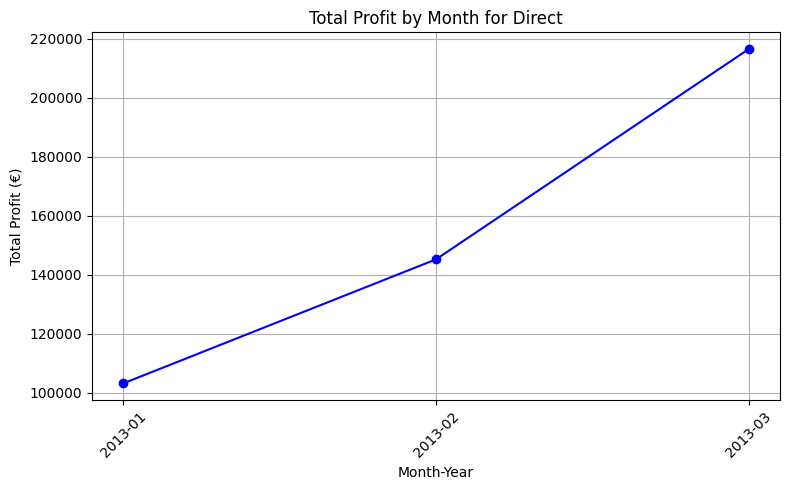

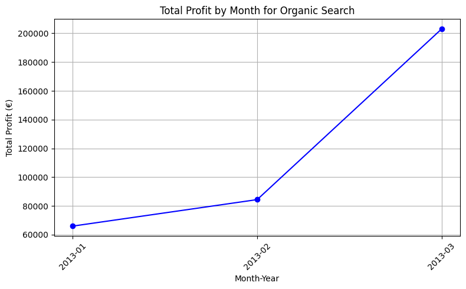

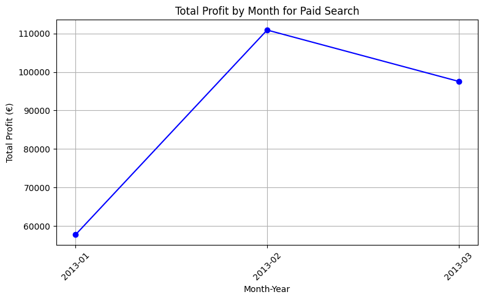

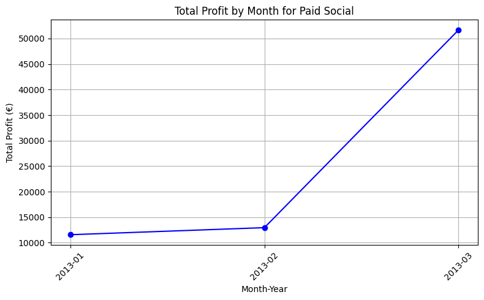

```python
# Step 1: Ensure 'Registration Date' is in datetime format and extract 'Month-Year'
merged_df['Registration Date'] = pd.to_datetime(merged_df['Registration Date'], dayfirst=True)
merged_df['Month-Year'] = merged_df['Registration Date'].dt.to_period('M')  # To ensure proper sorting by month

# Step 2: Calculate total profit for each customer (1st Order Profit + Subsequent Order Profit)
merged_df['Total Profit'] = merged_df['1st Order Profit'] + merged_df['Subsequent Order Profit'] - merged_df["Total value of all promotions"]

# Step 3: Group by 'Month-Year' and 'Source of Customer' to calculate total profit by month and channel
monthly_profit_by_channel = merged_df.groupby(['Month-Year', 'Source of Customer'])['Total Profit'].sum().unstack()

# Step 4: Plot individual time series of total profit by month for each marketing channel
for column in monthly_profit_by_channel.columns:
    plt.figure(figsize=(8, 5))
    plt.plot(monthly_profit_by_channel.index.astype(str), monthly_profit_by_channel[column], marker='o', linestyle='-', color='b')

    # Customize the plot for each channel
    plt.title(f'Total Profit by Month for {column}')
    plt.xlabel('Month-Year')
    plt.ylabel('Total Profit (€)')
    plt.xticks(rotation=45)
    plt.grid(True)
    plt.tight_layout()
    plt.show()
```

Interestingly, the above time series plots show that the profits for each source are increasing over time, with organic search having the highest rate of change from feb-march. Except for paid search, who's rate of changed actually became negative, and profit total went down from feb-march